# Milestone Report

Nikhil Parimi

2024-12-25

## Loading the data

For this report we will be considering analysing information from the English database, with the data downloaded from: https://d396qusza40orc.cloudfront.net/dsscapstone/dataset/Coursera-SwiftKey.zip, containing twitter, news and blog data.

```r
con <- file("data/final/en_US/en_US.blogs.txt", open = "r")
blogs <- readLines(con, encoding = "UTF-8", skipNul = TRUE)
close(con)

con <- file("data/final/en_US/en_US.news.txt", open = "r")
news <- readLines(con, encoding = "UTF-8", skipNul = TRUE)
close(con)

con <- file("data/final/en_US/en_US.twitter.txt", open = "r")
twitter <- readLines(con, encoding = "UTF-8", skipNul = TRUE)
close(con)

rm(con)
```

## Data Summary

We will now delve into the data to gain more insight into the information. Here we will explore the: number of lines, number of characters, number of words as well as average words per line (WPL) in each of the 3 source files.

```r
file_names = c("en_US.blogs.txt", "en_US.news.txt", "en_US.twitter.txt")
num_lines <- sapply(list(blogs, news, twitter), length)
num_char <- sapply(list(nchar(blogs), nchar(news), nchar(twitter)), sum)

words_blogs <- str_count(blogs, "\\S+")
words_news <- str_count(news, "\\S+")
words_twitter <- str_count(twitter, "\\S+")

num_words <- sapply(list(words_blogs, words_news, words_twitter), sum)

avg_wpl <- sapply(list(words_blogs, words_news, words_twitter), mean)

summary <- data.frame(
  File = file_names,
  Lines = num_lines,
  Characters = num_char,
  Words = num_words,
  Average_WPL = avg_wpl
  )

kable(summary, format = "pipe", digits = 2, caption = "Summary of Files")
```

Summary of Files

| File | Lines | Characters | Words | Average_WPL |
| --- | --- | --- | --- | --- |
| en_US.blogs.txt | 899288 | 206824505 | 37334131 | 41.52 |
| en_US.news.txt | 77259 | 15639408 | 2643969 | 34.22 |
| en_US.twitter.txt | 2360148 | 162096241 | 30373583 | 12.87 |

A few plots showing the spread of the line length can be seen below.

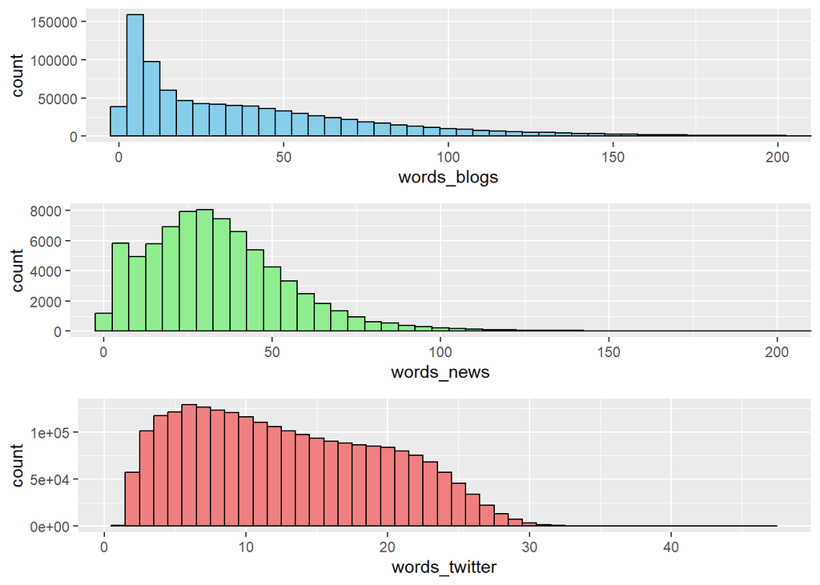

The x limit for words in blogs and news was truncated to 200 each respectively as the maximum values for number of words in a line reached almost 7000 and 2000 words respectively.

## Sampling

As mentioned in the brief, it is not necessary for all information to be used to build predictive models and more often than not, a few randomly selected samples can get an accurate approximation to results.

Here we will take a 5% sample of the data to work with which comes out to 3520690 words! We will then be performing some data cleaning on it before performing some data analysis to get a better understanding of the data.

```r
sample_size <- 0.05
# For reproducibility
set.seed(120)

sample_blogs <- sample(blogs, length(blogs) * sample_size, replace = FALSE)
sample_news <- sample(news, length(news) * sample_size, replace = FALSE)
sample_twitter <- sample(twitter, length(twitter) * sample_size, replace = FALSE)
```

## Combine data

We will also consider all of the data as one; will consequently require us to merge all 3 samples into 1.

```r
sample_data <- c(sample_blogs, sample_news, sample_twitter)
sample_fileName <- "data/final/en_US/en_US.sample.txt"
con <- file(sample_fileName, open = "w")
writeLines(sample_data, con)
close(con)
```

## Cleaning

Here we will make convert the data into a usable format to proceed further. The subheadings below will detail all the cleaning done step by step.

### Email / URL removal

The section of code will remove all email and urls present in the data.

```r
library("qdapRegex")
sample_data <- rm_email(sample_data)
sample_data <- rm_url(sample_data)
```

### Removal of non-english characters and punctuation.

```r
sample_data <- rm_non_ascii(sample_data)
sample_data <- rm_default(sample_data, pattern = "[^A-Za-z ]")
```

### Convert all words to lowercase

```r
sample_data <- tolower(sample_data)
```

### Tokenisation

Tokenisation is the process of replacing sensitive data with unique identification symbols that retain all the essential information about the data. Here the tokenisation will be to split the sentences into its constituent parts (words).

```r
tokenised <- strsplit(sample_data, "\\s")
```

### Profanity Filtering

This list was acquired from https://github.com/dsojevic/profanity-list and will filter out based on the list.

```r
con <- file("data/profanities.txt", open = "r")
profanities <- readLines(con, encoding = "UTF-8", skipNul = TRUE)
close(con)

cleaned_data <- lapply(tokenised, setdiff, y = profanities)
```

## Explore the Data

```r
# Sample of some data:
print(cleaned_data[514:516])
```

```
## [[1]]
##  [1] "came"         "across"       "your"         "blog"         "recently"
##  [6] "youve"        "offered"      "real"         "sound"        "advice"
## [11] "to"           "some"         "exasperating" "life"         "situations"
## [16] "i"            "hope"         "services"     "can"          "be"
## [21] "made"         "accessible"   "for"          "me"
##
## [[2]]
## [1] "cans" "of"   "beer"
##
## [[3]]
##  [1] "you"   "can"   "find"  "their" "blogs" "with"  "a"     "click" "on"
## [10] "names"
```

Number of lines:

```r
length(cleaned_data)
```

```
## [1] 166833
```

Number of words:

```r
sum(sapply(cleaned_data, length))
```

```
## [1] 2887554
```

### Word Frequencies

Here we will explore the 20 words that appear most frequently.

```r
word_freq <- table(unlist(cleaned_data))
word_freq_df <- as.data.frame(word_freq)
colnames(word_freq_df) <- c("Word", "Frequency")

top_20_words <- word_freq_df|>
  arrange(desc(Frequency)) |>
  head(20)

top_20_words$Word <- as.character(top_20_words$Word)
```

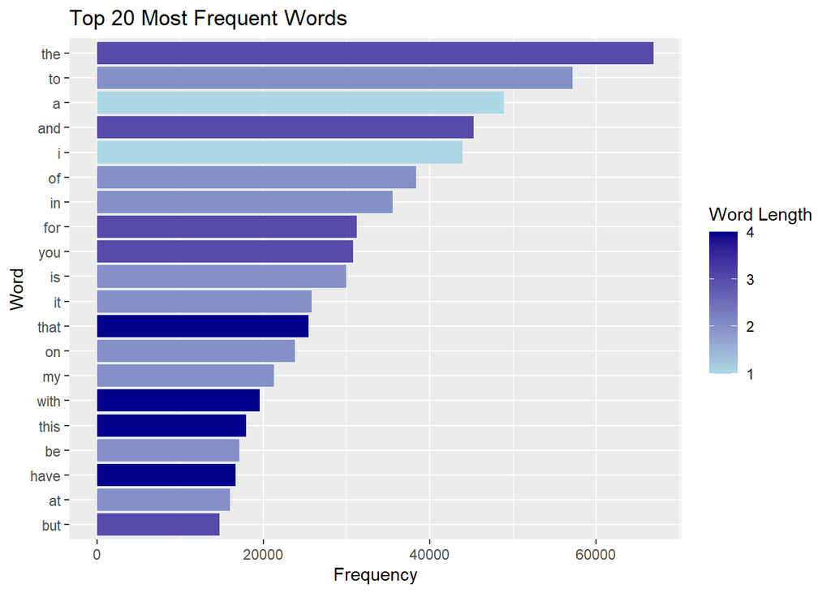

Now we will do a test to see if the top 5000 most frequent words in the English language and compare it to the top 5000 words from my sample data.

```r
con <- file("data/5000-words.txt", open = "r")
common <- readLines(con, encoding = "UTF-8", skipNul = TRUE)
close(con)

rm(con)
```

Clean the data to be of the same form of the sample data. (Lowercase, no punctuation etc.)

```r
common <- rm_default(common, pattern = "[^A-Za-z ]")

common <- tolower(common)
length(common)
```

```
## [1] 5000
```

Getting the top 5000 most frequent words from the sample data.

```r
common_freq_df <- word_freq_df|>
  arrange(desc(Frequency)) |>
  head(5000)

common_sample <- as.character(common_freq_df$Word)
```

Checking the number of words that are the same between the two lists

```r
common_words <- intersect(common, common_sample)

in_common <- length(common_words)

print(paste("Number of words in common: ", in_common))
```

```
## [1] "Number of words in common:  2798"
```

```r
print(paste("Percentage of words in common", (in_common/5000)*100, "%"))
```

```
## [1] "Percentage of words in common 55.96 %"
```

Only about 56% of the top 5000 words are covered by sample of 5% of the data. This is something that could definitely be improved by increasing the sample size.

### N-Grams

Now we will look at N-grams which are a sequence of n adjacent symbols in a particular order. With respect to words, n-grams can capture vital information with regards to word order that can be used to create predictive models.

### Bi-Grams (2-Grams)

```r
library(tidytext)

tb_sample_data <- tibble(txt = sample_data)

bigrams <- tb_sample_data |>
  unnest_ngrams(phrases, txt, n = 2)

bigram_freq <- bigrams |>
    count(phrases, sort = TRUE)

top_10_bigrams <- head(bigram_freq, 10)
top_10_bigrams
```

```
## # A tibble: 10 × 2
##    phrases     n
##    <chr>   <int>
##  1 of the  13168
##  2 in the  12236
##  3 for the  6960
##  4 to the   6695
##  5 on the   6419
##  6 to be    6000
##  7 at the   4488
##  8 i have   4103
##  9 and the  3863
## 10 i was    3740
```

Now we will visualise the data below.

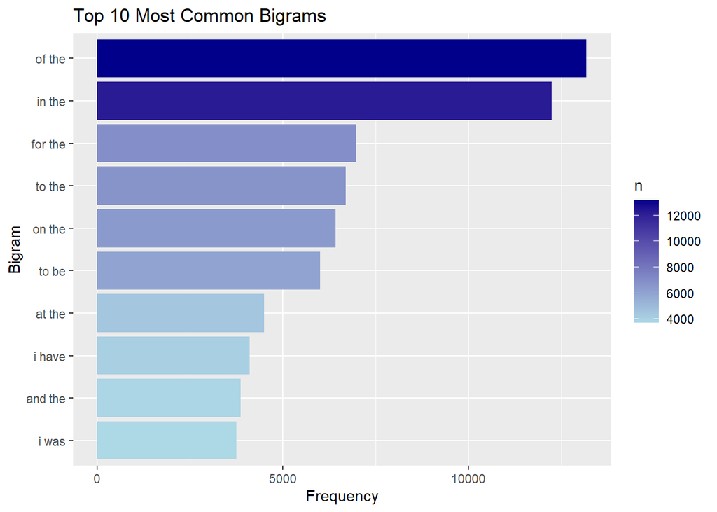

### Tri-Grams (3-grams)

```r
trigrams <- tb_sample_data |>
  unnest_ngrams(phrases, txt, n = 3)

trigram_freq <- trigrams |>
  # Filter NA vals
  filter(!is.na(phrases)) |>
  count(phrases, sort = TRUE)

top_10_trigrams <- head(trigram_freq, 10)
top_10_trigrams
```

```
## # A tibble: 10 × 2
##    phrases                n
##    <chr>              <int>
##  1 thanks for the      1244
##  2 one of the          1109
##  3 a lot of             987
##  4 i want to            712
##  5 to be a              706
##  6 going to be          641
##  7 i have a             561
##  8 i have to            522
##  9 it was a             513
## 10 looking forward to   498
```

Now we will visualise the data below.

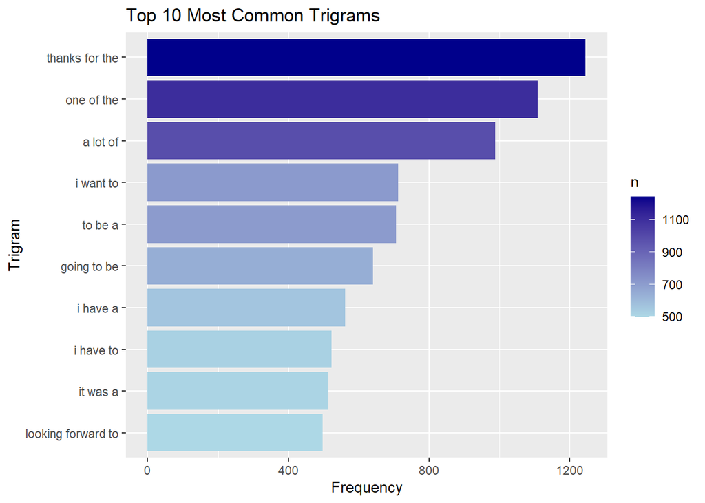

## Conclusion

In conclusion, we have set up a lot of things like the processing and tokenisation of data that can be used when building a predictive model.

## Goals

1. See how Sample Size affects word coverage
2. Build a predictive model on the data
3. Build a Shiny App with an accompanying presentation explaining the application.

Thank you!